# R Notebook

mwinkler

### Load data:

```r
setwd('/Users/matt.winkler/Documents/repos/kaggle--home-credit-default-risk/src')
train <-fread('../data/application_train.csv', stringsAsFactors = FALSE, showProgress=F,
              data.table = F, na.strings=c("NA","NaN","?", ""))
test <-fread('../data/application_test.csv', stringsAsFactors = FALSE, showProgress=F,
             data.table = F, na.strings=c("NA","NaN","?", ""))
bureau <-fread('../data/bureau.csv', stringsAsFactors = FALSE, showProgress=F,
               data.table = F, na.strings=c("NA","NaN","?", ""))
prev <-fread('../data/previous_application.csv', stringsAsFactors = FALSE, showProgress=F,
             data.table = F, na.strings=c("NA","NaN","?", ""))
```

```r
# summarize train dataset:
train.X %>% skim() %>% kable()
```

```
Skim summary statistics
 n obs: 307511
 n variables: 120

Variable type: character

|          variable          | missing | complete |   n    | min | max | empty | n_unique |
|----------------------------|---------|----------|--------|-----|-----|-------|----------|
|        CODE_GENDER         |    0    |  307511  | 307511 |  1  |  3  |   0   |    3     |
|    EMERGENCYSTATE_MODE     | 145755  |  161756  | 307511 |  2  |  3  |   0   |    2     |
|        FLAG_OWN_CAR        |    0    |  307511  | 307511 |  1  |  1  |   0   |    2     |
|      FLAG_OWN_REALTY       |    0    |  307511  | 307511 |  1  |  1  |   0   |    2     |
|     FONDKAPREMONT_MODE     | 210295  |  97216   | 307511 | 13  | 21  |   0   |    4     |
|       HOUSETYPE_MODE       | 154297  |  153214  | 307511 | 14  | 16  |   0   |    3     |
|     NAME_CONTRACT_TYPE     |    0    |  307511  | 307511 | 10  | 15  |   0   |    2     |
|    NAME_EDUCATION_TYPE     |    0    |  307511  | 307511 | 15  | 29  |   0   |    5     |
|     NAME_FAMILY_STATUS     |    0    |  307511  | 307511 |  5  | 20  |   0   |    6     |
|     NAME_HOUSING_TYPE      |    0    |  307511  | 307511 | 12  | 19  |   0   |    6     |
|      NAME_INCOME_TYPE      |    0    |  307511  | 307511 |  7  | 20  |   0   |    8     |
|      NAME_TYPE_SUITE       |  1292   |  306219  | 307511 |  6  | 15  |   0   |    7     |
|      OCCUPATION_TYPE       |  96391  |  211120  | 307511 |  7  | 21  |   0   |    18    |
|     ORGANIZATION_TYPE      |    0    |  307511  | 307511 |  3  | 22  |   0   |    58    |
|     WALLSMATERIAL_MODE     | 156341  |  151170  | 307511 |  5  | 12  |   0   |    7     |
| WEEKDAY_APPR_PROCESS_START |    0    |  307511  | 307511 |  6  |  9  |   0   |    7     |

Variable type: integer

|          variable           | missing | complete |   n    |   mean   |    sd     |   p0   |  p25   |  p50   |  p75   |  p100  |   hist   |
|-----------------------------|---------|----------|--------|----------|-----------|--------|--------|--------|--------|--------|----------|
|        CNT_CHILDREN         |    0    |  307511  | 307511 |   0.42   |   0.72    |   0    |   0    |   0    |   1    |   19   | ▇▁▁▁▁▁▁▁ |
|         DAYS_BIRTH          |    0    |  307511  | 307511 |  -16037  |  4363.99  | -25229 | -19682 | -15750 | -12413 | -7489  | ▃▆▆▆▇▇▇▃ |
|        DAYS_EMPLOYED        |    0    |  307511  | 307511 | 63815.05 | 141275.77 | -17912 | -2760  | -1213  |  -289  | 365243 | ▇▁▁▁▁▁▁▂ |
|       DAYS_ID_PUBLISH       |    0    |  307511  | 307511 | -2994.2  |  1509.45  | -7197  | -4299  | -3254  | -1720  |   0    | ▁▁▅▇▅▅▅▃ |
|      FLAG_CONT_MOBILE       |    0    |  307511  | 307511 |    1     |   0.043   |   0    |   1    |   1    |   1    |   1    | ▁▁▁▁▁▁▁▇ |
|      FLAG_DOCUMENT_10       |    0    |  307511  | 307511 | 2.3e-05  |  0.0048   |   0    |   0    |   0    |   0    |   1    | ▇▁▁▁▁▁▁▁ |
|      FLAG_DOCUMENT_11       |    0    |  307511  | 307511 |  0.0039  |   0.062   |   0    |   0    |   0    |   0    |   1    | ▇▁▁▁▁▁▁▁ |
|      FLAG_DOCUMENT_12       |    0    |  307511  | 307511 | 6.5e-06  |  0.0026   |   0    |   0    |   0    |   0    |   1    | ▇▁▁▁▁▁▁▁ |
|      FLAG_DOCUMENT_13       |    0    |  307511  | 307511 |  0.0035  |   0.059   |   0    |   0    |   0    |   0    |   1    | ▇▁▁▁▁▁▁▁ |
|      FLAG_DOCUMENT_14       |    0    |  307511  | 307511 |  0.0029  |   0.054   |   0    |   0    |   0    |   0    |   1    | ▇▁▁▁▁▁▁▁ |
|      FLAG_DOCUMENT_15       |    0    |  307511  | 307511 |  0.0012  |   0.035   |   0    |   0    |   0    |   0    |   1    | ▇▁▁▁▁▁▁▁ |
```

[output cut: 83 more lines]

```
|   NONLIVINGAPARTMENTS_MODE   | 213514  |  93997   | 307511 |  0.0081   |   0.046   |    0    |    0    |   0    | 0.0039 |    1     | ▇▁▁▁▁▁▁▁ |
|      NONLIVINGAREA_AVG       | 169682  |  137829  | 307511 |   0.028   |   0.07    |    0    |    0    | 0.0036 | 0.028  |    1     | ▇▁▁▁▁▁▁▁ |
|      NONLIVINGAREA_MEDI      | 169682  |  137829  | 307511 |   0.028   |   0.07    |    0    |    0    | 0.0031 | 0.027  |    1     | ▇▁▁▁▁▁▁▁ |
|      NONLIVINGAREA_MODE      | 169682  |  137829  | 307511 |   0.027   |   0.07    |    0    |    0    | 0.0011 | 0.023  |    1     | ▇▁▁▁▁▁▁▁ |
|   OBS_30_CNT_SOCIAL_CIRCLE   |  1021   |  306490  | 307511 |   1.42    |    2.4    |    0    |    0    |   0    |   2    |   348    | ▇▁▁▁▁▁▁▁ |
|   OBS_60_CNT_SOCIAL_CIRCLE   |  1021   |  306490  | 307511 |   1.41    |   2.38    |    0    |    0    |   0    |   2    |   344    | ▇▁▁▁▁▁▁▁ |
|         OWN_CAR_AGE          | 202929  |  104582  | 307511 |   12.06   |   11.94   |    0    |    5    |   9    |   15   |    91    | ▇▅▁▁▁▁▁▁ |
|  REGION_POPULATION_RELATIVE  |    0    |  307511  | 307511 |   0.021   |   0.014   | 0.00029 |  0.01   | 0.019  | 0.029  |  0.073   | ▆▆▇▅▁▁▁▁ |
|        TOTALAREA_MODE        | 148431  |  159080  | 307511 |    0.1    |   0.11    |    0    |  0.041  | 0.069  |  0.13  |    1     | ▇▂▁▁▁▁▁▁ |
| YEARS_BEGINEXPLUATATION_AVG  | 150007  |  157504  | 307511 |   0.98    |   0.059   |    0    |  0.98   |  0.98  |  0.99  |    1     | ▁▁▁▁▁▁▁▇ |
| YEARS_BEGINEXPLUATATION_MEDI | 150007  |  157504  | 307511 |   0.98    |   0.06    |    0    |  0.98   |  0.98  |  0.99  |    1     | ▁▁▁▁▁▁▁▇ |
| YEARS_BEGINEXPLUATATION_MODE | 150007  |  157504  | 307511 |   0.98    |   0.065   |    0    |  0.98   |  0.98  |  0.99  |    1     | ▁▁▁▁▁▁▁▇ |
|       YEARS_BUILD_AVG        | 204488  |  103023  | 307511 |   0.75    |   0.11    |    0    |  0.69   |  0.76  |  0.82  |    1     | ▁▁▁▁▁▇▇▂ |
|       YEARS_BUILD_MEDI       | 204488  |  103023  | 307511 |   0.76    |   0.11    |    0    |  0.69   |  0.76  |  0.83  |    1     | ▁▁▁▁▁▇▇▂ |
|       YEARS_BUILD_MODE       | 204488  |  103023  | 307511 |   0.76    |   0.11    |    0    |   0.7   |  0.76  |  0.82  |    1     | ▁▁▁▁▁▇▇▂ |
```

```r
# mean of target:
mean(train$TARGET)
```

```
[1] 0.08072882
```

At a high level, the dataset shows several columns that each have a high proportion of missing values, and a target variable that is unbalanced, though not severely. There are also numerous housing stock-related columns (.e.g COMMONAREA_AVG, COMMONAREA_MEDI, COMMONAREA_MODE) that seem to have a high potential for redundancy.

## Next steps:

1. Check correlations in housing stock features
2. Drop redundant features
3. Impute missing numerics
4. Impute missing categoricals

#### Correlations in housing stock:

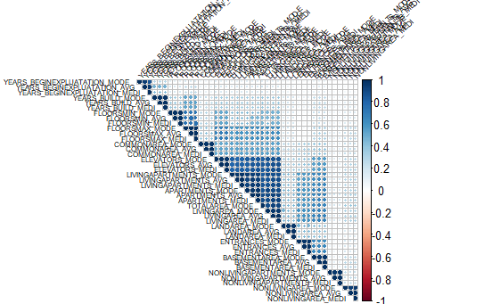

Each set of _Avg, _MEDI, and _MODE housing variables shows close to 100% correlation. Keep the _MEDI ones to simplify.

#### Drop redundant housing numerics:

```r
ncol(train.X)
```

```
[1] 92
```

#### Impute Missing Numeric variables:

```r
#convert characters to factors:
for (i in (1:ncol(train.X)) ) {
  if (class(train.X[, i]) == "character") {
    print("true")
  }
}
```

```
[1] "true"
[1] "true"
[1] "true"
[1] "true"
[1] "true"
[1] "true"
[1] "true"
[1] "true"
[1] "true"
[1] "true"
[1] "true"
[1] "true"
[1] "true"
[1] "true"
[1] "true"
[1] "true"
```

```r
names(train.X[, nums])
```

```
 [1] "AMT_INCOME_TOTAL"             "AMT_CREDIT"
 [3] "AMT_ANNUITY"                  "AMT_GOODS_PRICE"
 [5] "REGION_POPULATION_RELATIVE"   "DAYS_REGISTRATION"
 [7] "OWN_CAR_AGE"                  "CNT_FAM_MEMBERS"
 [9] "EXT_SOURCE_1"                 "EXT_SOURCE_2"
[11] "EXT_SOURCE_3"                 "APARTMENTS_MEDI"
[13] "BASEMENTAREA_MEDI"            "YEARS_BEGINEXPLUATATION_MEDI"
[15] "YEARS_BUILD_MEDI"             "COMMONAREA_MEDI"
[17] "ELEVATORS_MEDI"               "ENTRANCES_MEDI"
[19] "FLOORSMAX_MEDI"               "FLOORSMIN_MEDI"
[21] "LANDAREA_MEDI"                "LIVINGAPARTMENTS_MEDI"
[23] "LIVINGAREA_MEDI"              "NONLIVINGAPARTMENTS_MEDI"
[25] "NONLIVINGAREA_MEDI"           "TOTALAREA_MODE"
[27] "OBS_30_CNT_SOCIAL_CIRCLE"     "DEF_30_CNT_SOCIAL_CIRCLE"
[29] "OBS_60_CNT_SOCIAL_CIRCLE"     "DEF_60_CNT_SOCIAL_CIRCLE"
[31] "DAYS_LAST_PHONE_CHANGE"       "AMT_REQ_CREDIT_BUREAU_HOUR"
[33] "AMT_REQ_CREDIT_BUREAU_DAY"    "AMT_REQ_CREDIT_BUREAU_WEEK"
[35] "AMT_REQ_CREDIT_BUREAU_MON"    "AMT_REQ_CREDIT_BUREAU_QRT"
[37] "AMT_REQ_CREDIT_BUREAU_YEAR"
```

```r
# separate classes within the dataframe:
class.values <- sapply(train.X, class)
ints <- as.vector(class.values == "integer")
nums <- as.vector(class.values == "numeric")
chars <- as.vector(class.values == "character")
```

```r
sapply(train.X[, c(ints)], n_unique)
```

```r
# cast selected columns as numerics:
train.X$DAYS_BIRTH <- as.numeric(train.X$DAYS_BIRTH)
train.X$DAYS_EMPLOYED <- as.numeric(train.X$DAYS_EMPLOYED)
train.X$DAYS_ID_PUBLISH <- as.numeric(train.X$DAYS_ID_PUBLISH)
```

```r
# update class value assignments:
class.values <- sapply(train.X, class)
```

## Define plotting functions to look at individual variables:

```r
# core plotting for numeric data:
one_plot <- function(d, colname) {
  plot_ly(d, x = d[, colname], type="histogram") %>%
    add_annotations(
      ~unique(TARGET), x = 0.5, y = 1,
      xref = "paper", yref = "paper", showarrow = FALSE
    )
}
```

```r
# wrapper to call one_plot
plot.numeric <- function(data, colname) {
  #defines x axis
  x.axis <- list(
    title = colname,
    titlefont = list(
      family = "Courier New, monospace",
      size = 18,
      color = "#7f7f7f")
  )

  # split dataset by target values and call one_plot
  plt <- data %>%
    split(.$TARGET) %>%
    lapply(one_plot, colname=colname) %>%
    subplot(nrows = 2, shareX = TRUE, titleX = TRUE) %>%
    layout(xaxis = x.axis) %>%
    hide_legend()

  plt
}
```

```r
# plot proportion of total dataset:
plot.cat.1 <- function(data, colname) {
  data %>%
    mutate(TARGET=as.factor(TARGET)) %>%
    count(UQ(as.name(colname)), TARGET) %>%
    mutate(proportion = n / nrow(data)) %>%
    plot_ly(x = unique(select(data, colname)), y = ~proportion, color = ~TARGET, type="bar") %>%
     layout(barmode = "stack",
            title = colname)

}
```

```r
plot.cat.2 <- function(data, colname) {
  data$TARGET = as.factor(data$TARGET)
  ct = count(data, UQ(as.name(colname)), TARGET)
  ct.2 <- left_join(ct, count(ct, UQ(as.name(colname)), wt = n))
  ct.2 %>%
    mutate(prop = n / nn) %>%
    plot_ly(x = unique(select(data, colname)), y = ~prop, color = ~TARGET) %>%
    add_bars() %>%
    layout(barmode = "stack",
           title = colname)
}
```

```r
# Loop through columns and make plots:
train.X$TARGET <- y

for (i in 1:length(class.values)) {
  obj = class.values[i]
  cn = names(obj)
  cv = obj[[1]]
  # PDF setup:
  plotname = paste(cn, "_plot.pdf", sep="")
  if (cv == "numeric") {
    plt = plot.numeric(train.X, cn)
    print(plt)
  } else {
    cat.plt.1 <- plot.cat.1(train.X, cn)
    print(cat.plt.1)
    cat.plt.2 <- plot.cat.2(train.X, cn)
    print(cat.plt.2)
  }
}
```

From looking at the kable() output above, there are numerous features with lots of NA values. Check the proportion of NAs in the data, remove those with > 30% NA for now.

```r
missing.pcts <- numeric(ncol(train.X))
n <- nrow(train.X)

for (i in 1:length(missing.pcts)) {
  col.values = train.X[, i]
  null.count = sum(is.na(col.values))
  null.pct <- null.count / n
  missing.pcts[i] = null.pct
}

# columns to get rid of due to missing data - TODO: optimize setting
drops <- names(train.X)[missing.pcts > .30]

train.X.filt = train.X[ , !(names(train.X) %in% drops)]
#rm(dt.copy.X) # get rid of this; can always get it back later if necessary
```

There are a large number of missing values in the statistics describing the type of housing sought by the applicant. Dig into this set of variables to determine their relationship to one another and to the target.

```r
#paste0(names(train.X), collapse="','")
house <- train.X[,c('APARTMENTS_AVG','BASEMENTAREA_AVG','YEARS_BEGINEXPLUATATION_AVG','YEARS_BUILD_AVG','COMMONAREA_AVG','ELEVATORS_AVG','ENTRANCES_AVG','FLOORSMAX_AVG','FLOORSMIN_AVG','LANDAREA_AVG','LIVINGAPARTMENTS_AVG','LIVINGAREA_AVG','NONLIVINGAPARTMENTS_AVG','NONLIVINGAREA_AVG','APARTMENTS_MODE','BASEMENTAREA_MODE','YEARS_BEGINEXPLUATATION_MODE','YEARS_BUILD_MODE','COMMONAREA_MODE','ELEVATORS_MODE','ENTRANCES_MODE','FLOORSMAX_MODE','FLOORSMIN_MODE','LANDAREA_MODE','LIVINGAPARTMENTS_MODE','LIVINGAREA_MODE','NONLIVINGAPARTMENTS_MODE','NONLIVINGAREA_MODE','APARTMENTS_MEDI','BASEMENTAREA_MEDI','YEARS_BEGINEXPLUATATION_MEDI','YEARS_BUILD_MEDI','COMMONAREA_MEDI','ELEVATORS_MEDI','ENTRANCES_MEDI','FLOORSMAX_MEDI','FLOORSMIN_MEDI','LANDAREA_MEDI','LIVINGAPARTMENTS_MEDI','LIVINGAREA_MEDI','NONLIVINGAPARTMENTS_MEDI','NONLIVINGAREA_MEDI','TOTALAREA_MODE')]

# categorical housing type columns with lots of missing values:
# HOUSETYPE_MODE, WALLSMATERIAL_MODE, EMERGENCYSTATE_MODE, FONDKAPREMONT_MODE
```